# Exploratory Analysis

## Impacts of College Life on Students Mental Health

### Authors

- Abdulbasit Abdalla (tooly206@uw.edu)
- Ekram Melash (Eam52@uw.edu)
- Alison Miles (amilles1@uw.edu)
- Angela Sun (sinuos2@uw.edu) ### Date

Spring 2024

### Abstract

Our main question is how dietary habits, academic major, and pandemic impacts correlate with mental health issues among college students. This inquiry is important because identifying these correlations can enable tailored mental health interventions within academic settings. To explore these relationships, we will develop an interactive web application that visualizes data through specific analyses, including stacked bar charts and box plots, highlighting trends and patterns in student mental health.

### Keywords

Keywords: Mental Health; College Students; Data Visualization; Academic Stress; Pandemic Effects ### Introduction Our project focuses on exploring the intricate relationships between various factors—such as academic major, dietary habits, and the impacts of the COVID-19 pandemic—and mental health among college students. We aim to leverage an interactive web application to analyze and visualize data gathered from health surveys and academic records. This approach allows us to identify and understand patterns and trends that may influence students’ mental well-being, providing a foundation for targeted mental health strategies and interventions within academic communities.

**Research Questions:**

1. **How do dietary habits correlate with mental health conditions among college students?**
   - This question investigates whether the quality of diet can influence mental health.
   - Understanding this relationship could guide the development of nutritional support programs as
   - part of comprehensive mental health strategies in colleges.
2. **Are certain academic majors more likely to be associated with higher levels of stress** **and mental health issues among students?**
   - By identifying the majors that correlate with higher stress, institutions can tailor specific
   - counseling and support services to alleviate academic pressure and enhance student well-being.
3. **What has been the impact of the COVID-19 pandemic on the mental and academic well-being of college students?**
   - Examining the specific mental effects of the pandemic is crucial as it offers insights into how
   - such global crises can affect student populations, guiding future emergency response strategies in educational settings.
4. **Does the geographic location of students play a role in their mental health outcomes?**
   - This question explores whether external environmental and cultural factors associated with
   - different geographic locations affect mental health, which could be vital for universities with diverse student bodies.

Our questions are motivated by the need to address the rising concerns over mental health issues in college environments. They are important as they help to pinpoint specific factors that can be addressed by university policies and support systems, ultimately aiming to improve the educational and personal outcomes for students. ### Related Work

### The Dataset

**Where did you find the data?** The data for our study was sourced from Kaggle, a platform for data science competitions and datasets. You can access the dataset via this link: [Kaggle](https://www.kaggle.com/datasets/akilesh23/student-mental-health-issues/data)

**Who collected the data?** The dataset was compiled by AKILESH S, who gathered the data to analyze mental health issues among college students.

**How was the data collected or generated?** The data was generated through survey responses provided by the students. These responses were self-reported, based on personal feelings or perceptions related to various aspects of mental health.

**Why was the data collected?** The primary purpose of collecting the data was to analyze the prevalence and distribution of mental health issues among students, providing insights into how these issues vary across different demographics and conditions.

**How many observations (rows) are in your data?** The dataset contains 468 observations (rows).

**How many features (columns) are in the data?** There are 18 features (columns) in the dataset.

**What, if any, ethical questions or questions of power do you need to consider when working with this data?** When working with this data, ethical considerations include ensuring the anonymity and confidentiality of the respondents. It’s crucial to handle the data in a way that respects the privacy of the individuals involved and avoids any misuse of sensitive information about their mental health.

**What are possible limitations or problems with this data? (at least 200 words)** The dataset presents several limitations:

Self-reported Data: The reliance on self-reported responses may lead to inaccuracies due to subjective interpretations of personal mental health states. Temporal and Departmental Bias: The short duration of data collection and concentration of respondents from specific departments (e.g., CSE) may not accurately reflect broader trends and may skew results towards particular demographics. Survey Design Flaws: The design of the survey, which in some cases restricted responses to a single choice where multiple responses might be applicable, could result in an incomplete representation of the students’ mental health conditions and behaviors. Gender Distribution: The uneven gender distribution with a higher percentage of male respondents might introduce a bias, potentially impacting the findings and their generalizability to the entire student population. These factors necessitate a cautious approach to interpreting the findings, considering the potential biases and limitations inherent in the dataset. Further research, perhaps with a more robust and comprehensive data collection method, would be beneficial to deepen the understanding of mental health dynamics among students.

### Implications

The findings from our study highlight practical implications for technology developers and policy makers. Developers have opportunities to create engaging mental health tracking apps, such as ones providing stress management advice tailored to students’ majors or apps monitoring dietary impacts on mental health tailored to university food options. For policy makers, there’s a clear need to enhance mental health resources on campuses, integrate mental health education into high-stress academic programs, and develop policies that address the ongoing mental health impacts from the COVID-19 pandemic. These measures could significantly improve the support systems for college students, fostering better mental health awareness and care.

### Limitations & Challenges

Challenges within our project idea would be such things as generalizability, underreporting, complexity of mental health, and the longitude of the studies of college student’s mental health. To provide more explanation, mental health is a complex issue, with many different diagnoses, affects, and responses. To conduct research on students’ mental health, it is difficult to pinpoint specifics in such a large group of people with such a broad topic. It is also valid to account for the fact that mental health is still stigmatized. Therefore, mental health could potentially be underreported by these universities and college students. This could skew the data, with potentially misleading results and not an entirely accurate portrayal of college student’s mental health. Furthermore, in order to completely accurately track the mental effects that being a college student has on an individual, it is important to conduct studies that are conducted over a long period of time. This way there is the utmost accuracy when discussing mental health effects. However, this would be a challenge, because it is not only hard to track, it is also operationally difficult.

## Data Manipulation

```r
library(dplyr)
library(tidyverse)
data_set <- read.csv("Survey on Student Mental Health1.csv")
```

```r
mutate_col_names <- data_set %>%
  mutate(
    age = Age,
    grade = Current_year_you_are_studying_in,
    major = Department,
    sleep_amount = How_much_time_are_you_sleeping_everyday,
    gpa = Cgpa,
    reason = Why_did_you_chosen_your_department_work_area,
    attitude = Are_you_happy_with_your_department_work_area,
    diet = Are_you_getting_good_food_diet_everyday
  )
```

## Data Aggregation

```r
agregated_data_frame <- mutate_col_names %>%
  group_by(major, reason, attitude, sleep_amount, diet) %>%
  summarize(
    average_gpa = mean(gpa, na.rm = TRUE),
    maximum_gpa = max(gpa, na.rm = TRUE),
    median_gpa = median(gpa, na.rm = TRUE),
    total_students = n(),
    .groups = "drop"
  )
```

## Display Aggregated Data

```
## # A tibble: 182 × 9
##     major  reason attitude sleep_amount diet  average_gpa maximum_gpa median_gpa
##     <chr>  <chr>  <chr>           <int> <chr>       <dbl>       <dbl>      <dbl>
##   1 "AERO" Futur… Yes                 6 No           8           8          8
##   2 "AERO" Futur… Yes                 6 Yes          8.1         8.1        8.1
##   3 "AERO" Futur… Yes                 8 Yes          8.5         8.5        8.5
##   4 "AERO" Inter… No                  5 No           9.13        9.13       9.13
##   5 "AERO" Inter… Yes                 5 No           8.9         9          8.9
##   6 "AERO" Inter… Yes                 5 Yes          9.34        9.34       9.34
##   7 "AERO" Inter… Yes                 6 No           6           6          6
##   8 "AERO" Inter… Yes                 6 Yes          8.7         8.7        8.7
##   9 "AERO" Inter… Yes                 8 No           8.30        8.5        8.30
##  10 "ARTS" Futur… Yes                 4 Yes          7           7          7
##  11 "ARTS" Inter… Yes                 8 No           6.3         6.3        6.3
##  12 "AUTO… Inter… Yes                 7 No           8           8          8
```

[output cut: 171 more lines]

The table created in the provided R script aggregates and analyzes data based on variables such as academic major, reasons for choosing that major, attitude towards the major, sleep amount, and diet, calculating important statistics like average, maximum, and median GPA, along with the total number of students per group. This aggregation is crucial as it provides insights into how different factors influence students’ academic performance and mental well-being, allowing for easy comparison across groups. Such structured data is invaluable for universities in making informed decisions regarding curriculum adjustments, student support services, and resource allocation. Additionally, it highlights patterns and potential areas for further research, ultimately aiming to improve educational outcomes and enhance student satisfaction by addressing specific needs identified through the analysis.

### Chart 1

The purpose of including Chart 1: Chart 1 is designed to answer our first research question: “Is there a relationship between mental health issues among college students and their dietary habits?” We intend to include this bar chart to visualize data about whether students had a good diet or notand their corresponding mental health conditions. Our initial hypothesis was that students with poor dietary habits were more likely to suffer from mental health issues, or that mental health problems led to poor dietary habits. Chart 1 aims to test this hypothesis. Notable observations and insights from Chart 1: Chart 1 illustrates the proportion of students with good and poor diets for each mental health condition. Through our observation, it is apparent that among students who felt depressed and stressed, a higher proportion had poor dietary habits, suggesting that poor eating habits led to more potential mental health issues such as depression, or the mental health problems diminish students’ willing of good diet, which is also in line with our guess. However, it is also notable that even for happy students, poor eating habits still predominate, which may weaken our previous conclusion.

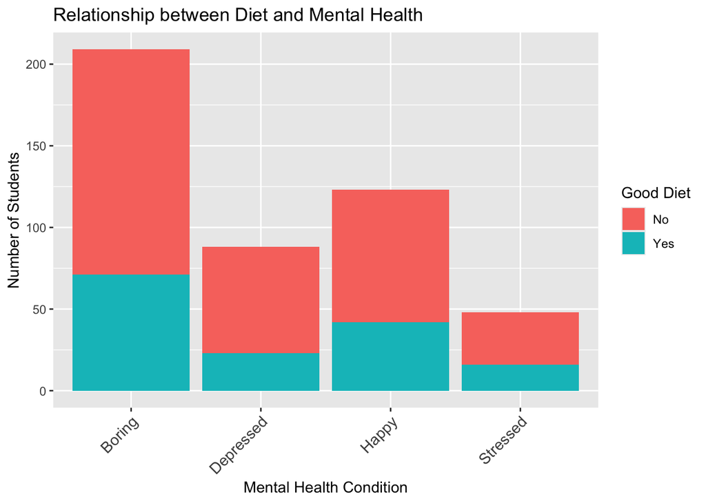

### Chart 2

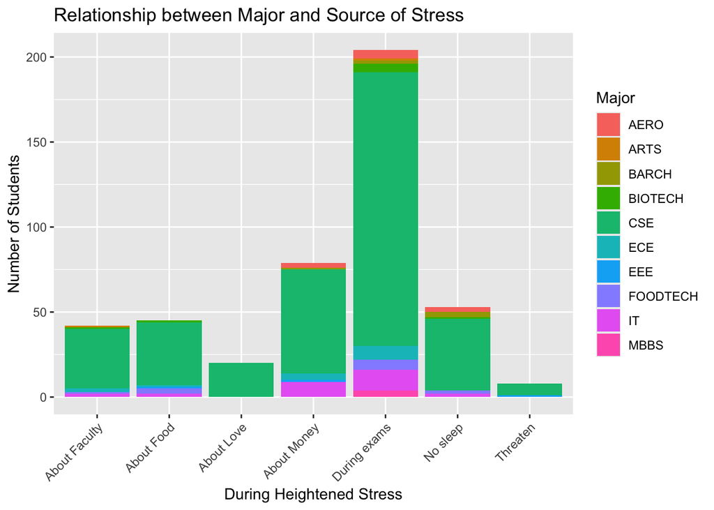

The purpose of including Chart 2:  
Chart 2 is designed to answer our second research question: “Do students who are studying a certain major report higher stress issues/levels?” We intend to include this bar chart to visualize the distributions of causes of stress and the distributions of departments that students enrolled in for each kind of source. We anticipated that students, regardless of their major, experience significant stress related to academic life. We were also curious to see which major reported the highest overall stress levels since almost all majors seemed to be challenging STEM majors. Notable observations and insights from Chart 2: Chart 2 shows that students of all majors reported high levels of stress related to exams compared with other sources of stress, which aligns with our expectations. Besides, under any circumstance, students majoring in CSE felt more pressure than those in any other major. Notably, we were surprised that CSE students were the only group reporting heightened stress related to love. Therefore, it appears that CSE students experience higher stress levels compared to students in other majors.

### Chart 3

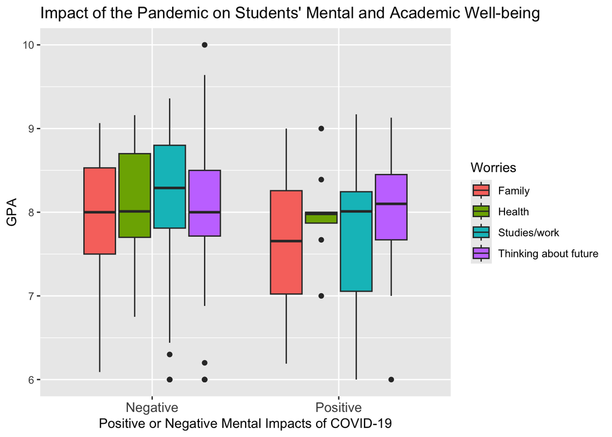

The purpose of including Chart 3:  
Chart 3 is designed to answer our third research question: “How did the pandemic affect the students’ well-being?” We include this box plot to display and compare the positive and negative pandemic’s mental effects on students’ overall well-being. Generally, we intended to see if COVID-19’s negative impacts on students’ mental health caused worse academic performance and more worries through this visualization. Notable observations and insights from Chart 3: We observed Chart 3 and found that there are apparent variations in grades occurred in both students with positive and negative mental impacts of the pandemic, and the median GPA was always higher in students suffering negative mental impacts from COVID-19 except students worrying about future. Besides, among all groups of students, students with positive mental impacts who worried about health had the least variation in grades if ignoring four outliers, which may imply that positive mental effects caused a specific group of students to worry about health, and grades around 8.0 were a shared feature.